# Análisis de Comunidades Bentónicas de Arrecifes de Coral

Dr. Juan Carlos Rubio-Polania

2026-05-14

> 💻 **Código fuente y repositorio:**  
> https://github.com/Keyanswers

> 📦 **Documentación del paquete `benthicR`:**  
> https://keyanswers.github.io/benthicR/

# 1 Descripción General

Este script realiza un análisis completo de datos de comunidades bentónicas (corales). Incluye:

1. Instalación y carga de paquetes especializados (`benthicR`, `dunn.test`, `dendextend`).
2. Carga y exploración de datos de cobertura en formato *wide* (especies en columnas, sitios en filas).
3. Cálculo de índices de diversidad local (Shannon, Hmax, LCBD) y evaluación de supuestos.
4. Comparación de diversidad observada vs. máxima (prueba de Wilcoxon).
5. Análisis de diferencias entre sitios mediante pruebas paramétricas (ANOVA) y no paramétricas (Kruskal-Wallis + Dunn test).
6. Análisis de la comunidad usando distancia de Bray-Curtis, *clustering* jerárquico y dendrogramas personalizados.
7. Instrucciones para calcular índices de rugosidad y proporción coral/alga.

# 2 Instalación y Carga de Paquetes

```r
# Instalar paquete benthicR desde GitHub (requiere devtools)
devtools::install_github("keyanswers/benthicR")

# Instalar paquetes adicionales
install.packages(c("readxl", "dunn.test", "dendextend"))
```

```r
# Paquete para manejo de datos y biodiversidad bentónica
require(benthicR)

# Paquete para abrir archivos de Excel
require(readxl)

# Paquete para pruebas de múltiples comparaciones
require(dunn.test)

# Paquete para personalizar dendrogramas
require(dendextend)

# Paquete para cálculo de momentos estadísticos
require(moments)
```

# 3 Carga y Exploración de Datos

> **Nota:** Los datos están disponibles dentro del paquete `benthicR` en `inst/extdata/`. Se acceden con `system.file()` para garantizar la reproducibilidad en cualquier computadora.

```r
# Cargar datos de coberturas simulados desde el paquete benthicR
# Formato "wide": especies en columnas, sitios en filas
path <- system.file("extdata", "CursoCorales.xlsx", package = "benthicR")
Data <- data.frame(read_excel(path, 1))

# Visualizar primeras filas y dimensiones
head(Data)
```

```
##   Sitios Transecto Porites_astreoides_ Siderastrea_siderea_
## 1 Isla_A       T1A                  18                   10
## 2 Isla_A       T2A                  15                   12
## 3 Isla_A       T3A                  16                    9
## 4 Isla_B       T1B                   6                    4
## 5 Isla_B       T2B                   7                    4
## 6 Isla_B       T3B                   5                    3
##   Agaricia_agaricites_ Orbicella_annularis_ Montastraea_cavernosa_
## 1                    6                    0                      3
## 2                    8                    0                      2
## 3                    5                    0                      4
## 4                   12                    3                      1
## 5                    8                    4                      1
## 6                   13                    5                      1
##   Pseudodiploria_clivosa_ Pocillopora_spp._ Porites_compressa_
## 1                       2                 0                  0
## 2                       1                 0                  0
## 3                       3                 0                  0
## 4                       1                 0                  0
## 5                       1                 0                  0
## 6                       1                 0                  0
##   Acropora_palmata_ Orbicella_faveolata_ Arena_ Filamentosas_
## 1                 0                    0     45            16
## 2                 0                    0     48            14
## 3                 0                    0     50            13
## 4                 0                    0     45            28
## 5                 3                    0     44            28
## 6                 0                    0     43            29
```

```r
dim(Data)
```

```
## [1] 15 14
```

```r
# Resumen exploratorio de las variables (especies)
summary(Data)
```

```
##     Sitios           Transecto         Porites_astreoides_ Siderastrea_siderea_
##  Length:15          Length:15          Min.   : 4.00       Min.   : 2.000
##  Class :character   Class :character   1st Qu.: 6.00       1st Qu.: 3.500
##  Mode  :character   Mode  :character   Median :11.00       Median : 9.000
##                                        Mean   :11.27       Mean   : 7.867
##                                        3rd Qu.:16.50       3rd Qu.:11.000
##                                        Max.   :19.00       Max.   :16.000
##  Agaricia_agaricites_ Orbicella_annularis_ Montastraea_cavernosa_
##  Min.   : 4.0         Min.   : 0.0         Min.   :0.000
##  1st Qu.: 6.0         1st Qu.: 2.5         1st Qu.:1.000
##  Median : 9.0         Median : 4.0         Median :1.000
##  Mean   : 9.4         Mean   : 5.0         Mean   :1.933
##  3rd Qu.:12.5         3rd Qu.: 6.5         3rd Qu.:3.000
##  Max.   :16.0         Max.   :13.0         Max.   :5.000
##  Pseudodiploria_clivosa_ Pocillopora_spp._ Porites_compressa_ Acropora_palmata_
##  Min.   :0.000           Min.   :0.0       Min.   :0.0000     Min.   :0.0000
##  1st Qu.:0.000           1st Qu.:0.0       1st Qu.:0.0000     1st Qu.:0.0000
##  Median :1.000           Median :0.0       Median :0.0000     Median :0.0000
##  Mean   :1.133           Mean   :0.2       Mean   :0.2667     Mean   :0.8667
##  3rd Qu.:2.000           3rd Qu.:0.0       3rd Qu.:0.0000     3rd Qu.:0.0000
##  Max.   :3.000           Max.   :1.0       Max.   :2.0000     Max.   :6.0000
##  Orbicella_faveolata_     Arena_      Filamentosas_
##  Min.   :0.00000      Min.   :35.00   Min.   :13.00
##  1st Qu.:0.00000      1st Qu.:40.50   1st Qu.:15.00
##  Median :0.00000      Median :44.00   Median :16.00
##  Mean   :0.06667      Mean   :43.67   Mean   :18.47
##  3rd Qu.:0.00000      3rd Qu.:49.00   3rd Qu.:19.50
##  Max.   :1.00000      Max.   :51.00   Max.   :29.00
```

```r
# Resumen exploratorio por sitios (ver función PreData)
summary(PreData(Data, ReCols = 1, transpose = TRUE))
```

```
##       T1A              T2A              T3A              T1B
##  Min.   : 0.000   Min.   : 0.000   Min.   : 0.000   Min.   : 0.000
##  1st Qu.: 0.000   1st Qu.: 0.000   1st Qu.: 0.000   1st Qu.: 0.000
##  Median : 2.500   Median : 1.500   Median : 3.500   Median : 2.000
##  Mean   : 8.333   Mean   : 8.333   Mean   : 8.333   Mean   : 8.333
##  3rd Qu.:11.500   3rd Qu.:12.500   3rd Qu.:10.000   3rd Qu.: 7.500
##  Max.   :45.000   Max.   :48.000   Max.   :50.000   Max.   :45.000
##       T2B              T3B              T1C              T2C
##  Min.   : 0.000   Min.   : 0.000   Min.   : 0.000   Min.   : 0.00
##  1st Qu.: 0.750   1st Qu.: 0.000   1st Qu.: 1.500   1st Qu.: 1.50
##  Median : 3.500   Median : 2.000   Median : 4.500   Median : 3.50
##  Mean   : 8.333   Mean   : 8.333   Mean   : 8.333   Mean   : 8.50
##  3rd Qu.: 7.250   3rd Qu.: 7.000   3rd Qu.:13.000   3rd Qu.:15.25
##  Max.   :44.000   Max.   :43.000   Max.   :35.000   Max.   :36.00
##       T3C              T1D              T2D              T3D
##  Min.   : 0.000   Min.   : 0.000   Min.   : 0.000   Min.   : 0.000
##  1st Qu.: 0.000   1st Qu.: 1.000   1st Qu.: 0.750   1st Qu.: 0.750
##  Median : 4.500   Median : 3.500   Median : 3.500   Median : 4.000
##  Mean   : 8.333   Mean   : 8.333   Mean   : 8.333   Mean   : 8.333
##  3rd Qu.:14.250   3rd Qu.:10.500   3rd Qu.:10.250   3rd Qu.:10.250
##  Max.   :35.000   Max.   :40.000   Max.   :42.000   Max.   :41.000
##       T1E              T2E              T3E
##  Min.   : 0.000   Min.   : 0.000   Min.   : 0.000
##  1st Qu.: 0.000   1st Qu.: 0.000   1st Qu.: 0.000
##  Median : 1.000   Median : 1.500   Median : 1.000
##  Mean   : 8.333   Mean   : 8.333   Mean   : 8.333
##  3rd Qu.:12.750   3rd Qu.:11.750   3rd Qu.:13.500
##  Max.   :50.000   Max.   :51.000   Max.   :50.000
```

```r
# Suma por filas para establecer el n de rarefacción (valores ordenados)
sort(rowSums(Data[, 3:12]))
```

```
##  [1] 27 28 28 34 34 35 37 38 39 40 40 40 49 50 51
```

# 4 Índices de Diversidad

## 4.1 Cálculo de Índices Locales

```r
# Índices de diversidad local (Shannon, Hmax, LCBD)
# Se excluyen arenas y algas. Ver función Div.
# LCBD: valores p corregidos (adpLCBD) indican si hay sitios diferenciados.
Index <- Div(Data[, 2:12], n = 27)
Index
```

```
##    Stations  N Richness Esn  Shannon     Hmax         J Dominance       LCBD
## 1       T1A 39        5   5 1.343428 1.609438 0.8347185 0.3109796 0.08571572
## 2       T2A 38        5   5 1.309653 1.609438 0.8137332 0.3033241 0.07239902
## 3       T3A 37        5   5 1.421063 1.609438 0.8829559 0.2826881 0.09818642
## 4       T1B 27        6   6 1.465820 1.791759 0.8180898 0.2839506 0.02223801
## 5       T2B 28        7   7 1.737808 1.945910 0.8930568 0.1989796 0.04265616
## 6       T3B 28        6   6 1.448827 1.791759 0.8086060 0.2933673 0.03817232
## 7       T1C 49        7   7 1.707972 1.945910 0.8777240 0.2178259 0.09396450
## 8       T2C 51        7   7 1.591157 1.945910 0.8176931 0.2579777 0.06938121
## 9       T3C 50        6   6 1.579778 1.791759 0.8816908 0.2424000 0.03932010
## 10      T1D 40        8   7 1.683109 2.079442 0.8094043 0.2175000 0.04083434
## 11      T2D 40        7   6 1.688942 1.945910 0.8679445 0.2100000 0.03978472
## 12      T3D 40        7   6 1.618902 1.945910 0.8319511 0.2212500 0.03485348
## 13      T1E 34        4   4 1.177151 1.386294 0.8491351 0.3442907 0.11049775
## 14      T2E 34        4   4 1.250771 1.386294 0.9022405 0.3131488 0.08667459
```

[output cut: 17 more lines]

## 4.2 Evaluación de Supuestos

```r
# Prueba de normalidad
NormalTest(Index)
```

```
##    Variables     W  p_SW    Status
## 1          N 0.923 0.210    Normal
## 2   Richness 0.900 0.096    Normal
## 3    Shannon 0.933 0.304    Normal
## 4       Hmax 0.883 0.053    Normal
## 5          J 0.882 0.051    Normal
## 6  Dominance 0.942 0.406    Normal
## 7       LCBD 0.916 0.169    Normal
## 8      pLCBD 0.882 0.052    Normal
## 9        Esn 0.870 0.034 Transform
## 10   adpLCBD 0.284 0.000 Transform
```

```r
# Homogeneidad de varianza por sitio (usando réplicas)
bartlett.test(Index$Shannon ~ Data$Sitios)  # Varianza homogénea
```

```
##
##  Bartlett test of homogeneity of variances
##
## data:  Index$Shannon by Data$Sitios
## Bartlett's K-squared = 4.4059, df = 4, p-value = 0.3539
```

```r
bartlett.test(Index$Hmax    ~ Data$Sitios)  # Varianza no homogénea
```

```
##
##  Bartlett test of homogeneity of variances
##
## data:  Index$Hmax by Data$Sitios
## Bartlett's K-squared = Inf, df = 4, p-value < 2.2e-16
```

## 4.3 Comparación H’ vs H<sub>max</sub>

```r
# Prueba de Mann-Whitney pareada: H' observado vs H' máximo
# Diferencias estadísticas indican que alguna condición influye en la diversidad
wilcox.test(Index$Shannon, Index$Hmax,
            paired   = TRUE,
            conf.int = TRUE)
```

```
##
##  Wilcoxon signed rank exact test
##
## data:  Index$Shannon and Index$Hmax
## V = 0, p-value = 6.104e-05
## alternative hypothesis: true location shift is not equal to 0
## 95 percent confidence interval:
##  -0.3058605 -0.2249598
## sample estimates:
## (pseudo)median
##     -0.2675481
```

# 5 Diferencias entre Sitios

## 5.1 Transformación de Datos

```r
# Transformar datos y agregar columna de sitios
D1 <- TransformData(Data[, 2:12], data_type = "bio", trans = "r4")
```

```
##
## ========================================
##    TRANSFORMATION SUMMARY (BIO)
## ========================================
##                  Metric Count
## 1       Input variables    10
## 2 Transformed variables    10
##
## Transformation applied: fourth_root
```

```r
head(D1)
```

```
##   Transecto Porites_astreoides_ Siderastrea_siderea_ Agaricia_agaricites_
## 1       T1A            2.059767             1.778279             1.565085
## 2       T2A            1.967990             1.861210             1.681793
## 3       T3A            2.000000             1.732051             1.495349
## 4       T1B            1.565085             1.414214             1.861210
## 5       T2B            1.626577             1.414214             1.681793
## 6       T3B            1.495349             1.316074             1.898829
##   Orbicella_annularis_ Montastraea_cavernosa_ Pseudodiploria_clivosa_
## 1             0.000000               1.316074                1.189207
## 2             0.000000               1.189207                1.000000
## 3             0.000000               1.414214                1.316074
## 4             1.316074               1.000000                1.000000
## 5             1.414214               1.000000                1.000000
## 6             1.495349               1.000000                1.000000
##   Pocillopora_spp._ Porites_compressa_ Acropora_palmata_ Orbicella_faveolata_
## 1                 0                  0          0.000000                    0
## 2                 0                  0          0.000000                    0
## 3                 0                  0          0.000000                    0
## 4                 0                  0          0.000000                    0
## 5                 0                  0          1.316074                    0
## 6                 0                  0          0.000000                    0
```

```r
D1$Sitios <- Data$Sitios
D1$Sitios
```

```
##  [1] "Isla_A" "Isla_A" "Isla_A" "Isla_B" "Isla_B" "Isla_B" "Isla_C" "Isla_C"
##  [9] "Isla_C" "Isla_D" "Isla_D" "Isla_D" "Isla_E" "Isla_E" "Isla_E"
```

```r
# Reordenar columnas: Sitios al inicio
D1 <- D1[, c(12, 1:11)]
D1
```

```
##    Sitios Transecto Porites_astreoides_ Siderastrea_siderea_
## 1  Isla_A       T1A            2.059767             1.778279
## 2  Isla_A       T2A            1.967990             1.861210
## 3  Isla_A       T3A            2.000000             1.732051
## 4  Isla_B       T1B            1.565085             1.414214
## 5  Isla_B       T2B            1.626577             1.414214
## 6  Isla_B       T3B            1.495349             1.316074
## 7  Isla_C       T1C            2.030543             1.861210
## 8  Isla_C       T2C            2.087798             2.000000
## 9  Isla_C       T3C            2.059767             1.934336
## 10 Isla_D       T1D            1.861210             1.681793
## 11 Isla_D       T2D            1.778279             1.732051
## 12 Isla_D       T3D            1.821160             1.778279
## 13 Isla_E       T1E            1.495349             1.189207
## 14 Isla_E       T2E            1.565085             1.316074
```

[output cut: 49 more lines]

```r
# Cambiar a formato largo para pruebas de múltiples comparaciones
D2 <- reshape2::melt(D1, id.vars = c("Sitios", "Transecto"))
head(D2)
```

```
##   Sitios Transecto            variable    value
## 1 Isla_A       T1A Porites_astreoides_ 2.059767
## 2 Isla_A       T2A Porites_astreoides_ 1.967990
## 3 Isla_A       T3A Porites_astreoides_ 2.000000
## 4 Isla_B       T1B Porites_astreoides_ 1.565085
## 5 Isla_B       T2B Porites_astreoides_ 1.626577
## 6 Isla_B       T3B Porites_astreoides_ 1.495349
```

## 5.2 Evaluación de Distribución

```r
# Prueba de normalidad por sitio
tapply(D2$value, D2$Sitios, shapiro.test)
```

```
## $Isla_A
##
##  Shapiro-Wilk normality test
##
## data:  X[[i]]
## W = 0.77144, p-value = 2.063e-05
##
##
## $Isla_B
##
##  Shapiro-Wilk normality test
##
## data:  X[[i]]
## W = 0.82137, p-value = 0.0001649
##
##
## $Isla_C
##
##  Shapiro-Wilk normality test
##
## data:  X[[i]]
## W = 0.80891, p-value = 9.568e-05
##
##
## $Isla_D
##
##  Shapiro-Wilk normality test
##
## data:  X[[i]]
## W = 0.82724, p-value = 0.0002145
##
##
## $Isla_E
##
##  Shapiro-Wilk normality test
##
## data:  X[[i]]
## W = 0.70444, p-value = 1.812e-06
```

```r
# Conteo de observaciones por sitio
table(D2$Sitios)
```

```
##
## Isla_A Isla_B Isla_C Isla_D Isla_E
##     30     30     30     30     30
```

```r
# Asimetría y curtosis
cat("Asimetría:", skewness(D2$value), "(0 = simétrico)\n")
```

```
## Asimetría: -0.04387144 (0 = simétrico)
```

```r
# Cercano a cero → podría usarse prueba paramétrica
cat("Curtosis:",  kurtosis(D2$value), "(3 = normal)\n")
```

```
## Curtosis: 1.337128 (3 = normal)
```

```r
# Distribución platicúrtica → atribuida a la transformación
```

```r
# Homogeneidad de varianza entre sitios
bartlett.test(D2$value ~ D2$Sitios)
```

```
##
##  Bartlett test of homogeneity of variances
##
## data:  D2$value by D2$Sitios
## Bartlett's K-squared = 1.6354, df = 4, p-value = 0.8024
```

> **Criterio de selección de prueba:**
> 1. **Enfoque conservador (no paramétrico):** usar Kruskal-Wallis + Dunn test.
> 2. **Enfoque flexible:** considerar ANOVA, dado que la platicurtosis es similar a una distribución normal.

## 5.3 Pruebas Estadísticas

```r
# 1. Prueba no paramétrica: Kruskal-Wallis + múltiples comparaciones (Dunn)
Dunn <- dunn.test(D2$value, D2$Sitios, method = "holm")
```

```
##   Kruskal-Wallis rank sum test
##
## data: x and group
## Kruskal-Wallis chi-squared = 4.2848, df = 4, p-value = 0.37
##
##
##                            Comparison of x by group
##                                     (Holm)
## Col Mean-|
## Row Mean |     Isla_A     Isla_B     Isla_C     Isla_D
## ---------+--------------------------------------------
##   Isla_B |  -0.089479
##          |     0.4644
##   Isla_C |  -1.229570  -1.140090
##          |     0.8754     0.8899
##   Isla_D |  -0.962674  -0.873195   0.266895
##          |     1.0000     0.9564     0.7895
##   Isla_E |   0.546132   0.635612   1.775703   1.508807
##          |     0.8775     1.0000     0.3789     0.5911
##
## alpha = 0.05
## Reject Ho if p <= alpha/2
```

```r
# 2. ANOVA paramétrico
ANOVA <- aov(value ~ Sitios, data = D2)
summary(ANOVA)
```

```
##              Df Sum Sq Mean Sq F value Pr(>F)
## Sitios        4   3.35  0.8367   1.387  0.241
## Residuals   145  87.50  0.6034
```

```r
# Consultar ZAR (2009) u otro libro de estadística para verificar supuestos del ANOVA
```

# 6 Análisis de la Comunidad

## 6.1 Distancia de Bray-Curtis

```r
# Calcular distancia de Bray-Curtis (ver función PreData)
D3   <- PreData(D1, ReCols = 1)
Bray <- vegan::vegdist(D3, method = "bray")
```

## 6.2 Clustering Jerárquico

> **Nota:** El valor de similitud del 60% se representa como 0.4 en R (disimilitud). Ver ZAR u otro libro de estadística para interpretación.

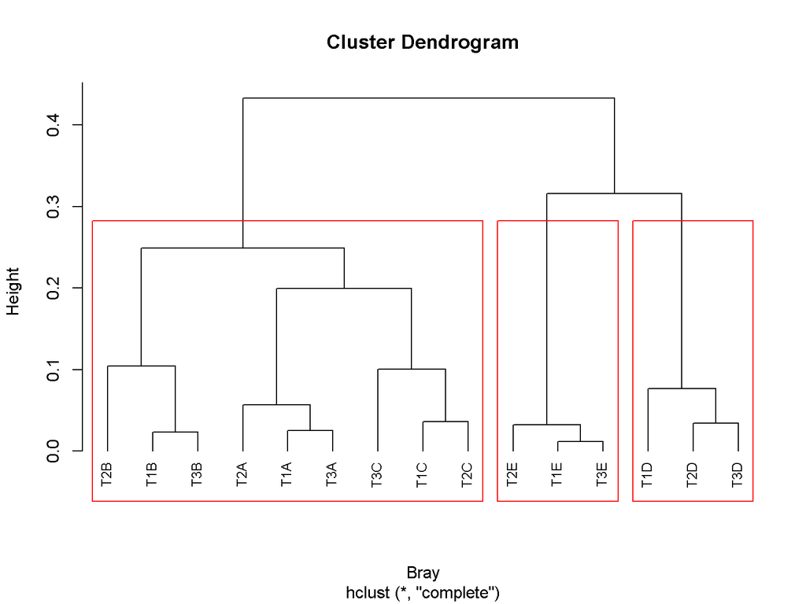

```r
# Calcular y graficar el análisis cluster estándar
p1 <- hclust(Bray)
plot(p1, hang = -1, cex = 0.8)

# Indicar grupos con rectángulos
rect.hclust(p1, k = 3, border = "red")
```

## 6.3 Dendrograma Personalizado

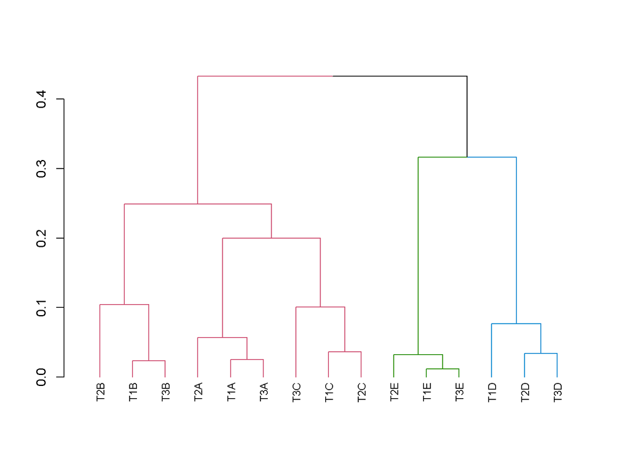

```r
# Colorear ramas por grupos con dendextend
dend <- as.dendrogram(p1)

dend <- dend %>%
  set("branches_k_color", k = 3) %>%   # colorear grupos
  set("labels_cex", 0.8)               # tamaño de etiquetas

plot(dend)
```

# 7 Razones Coral / Alga y Rugosidad

## 7.1 Proporción Coral / Alga

Las operaciones en R pueden realizarse por vectores o columnas:

1. Las algas son una columna en `Data`; se accede con el operador `$`.
2. Para el total de coral se usa `rowSums()` especificando el rango de columnas: `Data[, xi:xni]`. Asignar el resultado a un objeto, p. ej. `Corales`.
3. Definir la columna de transecto o sitio y calcular la razón.

```r
# Ejemplo orientativo (ajustar índices de columnas según la tabla)
Corales <- rowSums(Data[, 3:10])       # columnas de coral
Algas   <- Data$Algas                  # columna de algas
Razon   <- Corales / Algas
```

## 7.2 Índice de Rugosidad

1. Cargar los datos seleccionando la hoja correspondiente (cambiar el número en `read_excel`).
2. Visualizar la tabla.
3. Seleccionar las columnas y calcular el índice.

```r
# Cargar datos de rugosidad desde la hoja 2 del paquete benthicR
path <- system.file("extdata", "CursoCorales.xlsx", package = "benthicR")
DataRug <- data.frame(read_excel(path, 2))
head(DataRug)

# Calcular índice de rugosidad
# (ver funciones en https://keyanswers.github.io/benthicR/)
```

# 8 Referencias y Contacto

- Documentación de `benthicR`: https://keyanswers.github.io/benthicR/
- Repositorio GitHub: https://github.com/Keyanswers
- ZAR, J. H. (2009). *Biostatistical Analysis* (5th ed.). Prentice Hall.
- Contacto: juan.rubio@ecosur.mx

*Fecha límite de entrega: domingo.*